# IODS course project

Katja Häkkinen

# **Introduction to Open Data Science - Course Project**

### **This course has three big themes**

- open data
- open science
- data science

### **After completing the course students**

- understand possibilities of open science, open data, and open research tools
- master state-of-the-art, open and free software tools: RStudio and GitHub
- write dynamic reports (text, code, graphs, tables, etc.) in R Markdown
- apply the principle of reproducible research and see its practical advantages
- visualize and analyze data sets with some fairly advanced statistical methods
- learn much more of all this in the future (continuous learning)

### **My introduction**

I’m a PhD Candidate at University of Eastern Finland (Doctoral Programme of Clinical Research) doing pharmacogenomic research. We use population level health registry and genomic data in our research and I’m expecting to learn new tools and tips for coding and statistical analysis of big data during this course. Couple of other PhD students recommended this course as useful.

My GitHub repository can be found here: https://github.com/katjahakki/IODS-project

```r
# This is a so-called "R chunk" where you can write R code.

date()
```

```
## [1] "Sun Nov 28 19:52:45 2021"
```

# **Regression and model validation**

### **1. Structure of the data**

The original data file contains JYTOPKYS2 survey data concerning learning and teaching in a statistical course and reference to the data source can be found here https://www.mv.helsinki.fi/home/kvehkala/JYTmooc/JYTOPKYS2-meta.txt. A new analysis dataset learning2014 was created with variables gender, age, attitude, deep, stra, surf and points by combining questions from the original data file. All combination variables were scaled to the original scales by taking the mean and observations with exam points being zero were excluded.

The learning2014 dataset is a dataframe with 166 observations and 7 variables. The observations represent students in the statistical course (rows) and each column contains values of one variable.

Meaning of the variable abbreviations:  
attitude = attitude towards statistics  
deep = deep learning  
stra = strategic learning  
surf = surface learning  
points = total points of the course exam

```r
### RStudio exercise 2 - The Analysis exercise
date()
```

```
## [1] "Sun Nov 28 19:52:45 2021"
```

```r
# read in data,  learning2014.csv file, using read.csv()
learning2014 <- read.csv('~/IODS-project/data/learning2014.csv')

# show first 6 observations of the data
head(learning2014)
```

```
##   gender age attitude     deep  stra     surf points
## 1      F  53      3.7 3.583333 3.375 2.583333     25
## 2      M  55      3.1 2.916667 2.750 3.166667     12
## 3      F  49      2.5 3.500000 3.625 2.250000     24
## 4      M  53      3.5 3.500000 3.125 2.250000     10
## 5      M  49      3.7 3.666667 3.625 2.833333     22
## 6      F  38      3.8 4.750000 3.625 2.416667     21
```

```r
# data structure
str(learning2014)
```

```
## 'data.frame':    166 obs. of  7 variables:
##  $ gender  : chr  "F" "M" "F" "M" ...
##  $ age     : int  53 55 49 53 49 38 50 37 37 42 ...
##  $ attitude: num  3.7 3.1 2.5 3.5 3.7 3.8 3.5 2.9 3.8 2.1 ...
##  $ deep    : num  3.58 2.92 3.5 3.5 3.67 ...
##  $ stra    : num  3.38 2.75 3.62 3.12 3.62 ...
##  $ surf    : num  2.58 3.17 2.25 2.25 2.83 ...
##  $ points  : int  25 12 24 10 22 21 21 31 24 26 ...
```

```r
# data dimensions, rows and columns
dim(learning2014)
```

```
## [1] 166   7
```

```r
# number of rows in the data
nrow(learning2014)
```

```
## [1] 166
```

```r
# number of columns in the data
ncol(learning2014)
```

```
## [1] 7
```

Summary() function is a generic R function which produces **basic statistics** of the data. The function is also used to produce result summaries of the results of various model fitting functions.

```r
# summaries, basic statistics of the variables
summary(learning2014)
```

```
##     gender               age           attitude          deep
##  Length:166         Min.   :17.00   Min.   :1.400   Min.   :1.583
##  Class :character   1st Qu.:21.00   1st Qu.:2.600   1st Qu.:3.333
##  Mode  :character   Median :22.00   Median :3.200   Median :3.667
##                     Mean   :25.51   Mean   :3.143   Mean   :3.680
##                     3rd Qu.:27.00   3rd Qu.:3.700   3rd Qu.:4.083
##                     Max.   :55.00   Max.   :5.000   Max.   :4.917
##       stra            surf           points
##  Min.   :1.250   Min.   :1.583   Min.   : 7.00
##  1st Qu.:2.625   1st Qu.:2.417   1st Qu.:19.00
##  Median :3.188   Median :2.833   Median :23.00
##  Mean   :3.121   Mean   :2.787   Mean   :22.72
##  3rd Qu.:3.625   3rd Qu.:3.167   3rd Qu.:27.75
##  Max.   :5.000   Max.   :4.333   Max.   :33.00
```

```r
# distribution of female and male students
summary(as.factor(learning2014$gender))
```

```
##   F   M
## 110  56
```

Majority of the students are female students. We can see the minimum, first quartile, median, third quartile and maximum values of the numeric variables with the summary function.

### **2. Graphical overview of the data**

Let’s draw **a scatter plot matrix** of the data.

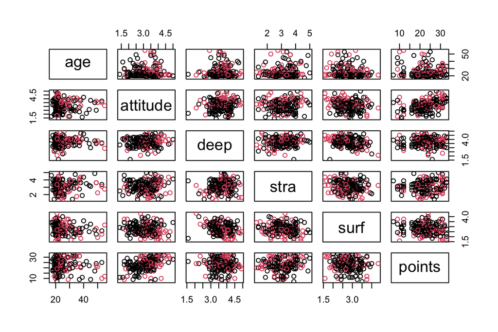

```r
# change variable gender from character to factor in order to draw a scatter plot
learning2014$gender = as.factor(learning2014$gender)

# draw a scatter plot matrix of the variables in learning2014
# [-1] excludes the first column (gender)
pairs(learning2014[-1], col=learning2014$gender)
```

Scatter plot matrices are a way to roughly determine if you have a linear correlation between multiple variables. The variables are in a diagonal line from top left to bottom right and each variable are plotted against each other. The boxes on the upper right of the scatter plot are mirror images of the plots on the lower left.

Let’s create **a more advanced plot matrix** of the data.

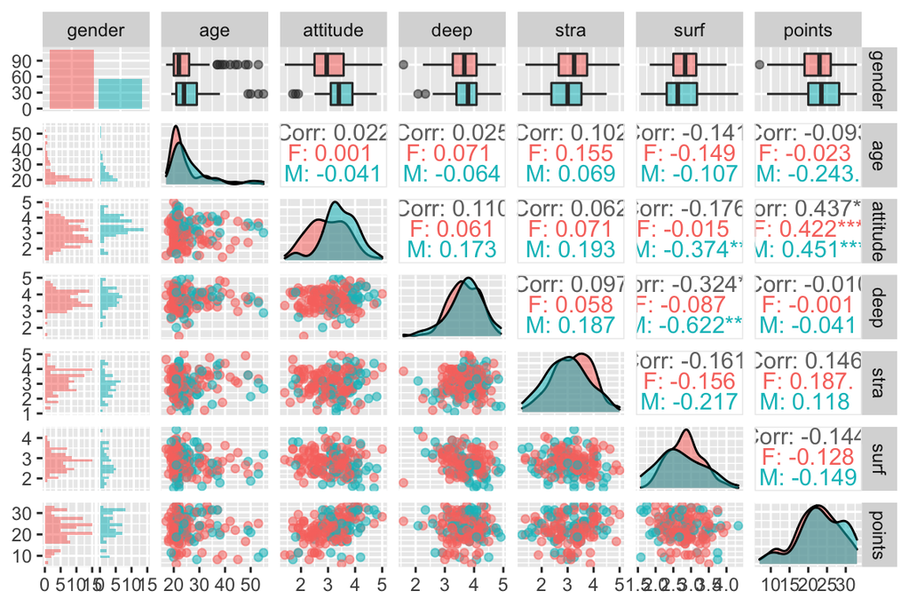

```r
# access the GGally and ggplot2 libraries
#install.packages("GGally")
library(GGally)
library(ggplot2)

# create plot matrix with ggpairs()
# Adjust the argument mapping of ggpairs() by defining col = gender inside aes().
# Adjust the code a little more: add another aesthetic element alpha = 0.3 inside aes().
p <- ggpairs(learning2014, mapping = aes(col = gender, alpha = 0.3), lower = list(combo = wrap("facethist", bins = 20)))

# draw the plot
p
```

The plot matrix can be used to visualize variable relationships for several variables in a single plot. Scatter plots of each pair of numeric variable are drawn on the left part of the plot, pearson correlation is shown on the right and variable distribution is displayed on the diagonal. This plot shows all data separately for female (red color) and male (green color) students. Up row shows boxplots and column on the left shows histograms of the variables. The boxplots display the distribution of data based on a five number summary: minimun, first quartile, median, third quartile and maximum. Outliers are shown as points outside of the boxes.

The strongest correlation is between points and attitude variables. When looking at the diagonal distributions, the age variable has a right-skewed distribution, the students are mainly of young age. The barplot in the up left corner shows the gender distribution, female students are the majority group.

Let’s draw a **scatter plot** of student’s attitude versus exam points with a **regression line**.

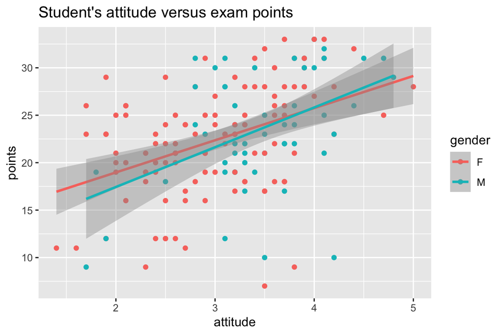

```r
# Access the ggplot2 library
library(ggplot2)

# initialize plot with data and aesthetic mapping
p1 <- ggplot(learning2014, aes(x = attitude, y = points, col = gender))

# define the visualization type (points)
p2 <- p1 + geom_point()

# add a regression line
p3 <- p2 + geom_smooth(method = "lm")

# add a main title and draw the plot
p4 <- p3 + ggtitle("Student's attitude versus exam points")

# draw the plot
p4
```

The plot and the regression line indicate a linear relationship between student’s attitude and exam points for both female and male students.

### **3. Fitting a regression model**

**Simple linear regression** models the relationship between the magnitude of one variable and that of a second - for example, as X increases, Y also increases. Or as X increases, Y decreases. Regression quantifies the nature of the relationship between the variables. The simple linear regression estimates how much Y will change when X changes by a certain amount. With regression, we predict the Y variable from X using a linear relationship.

When there are more than one explanatory variables in the linear model, it is called **multiple regression**. The response variable is assumed to be normally distributed with a mean that is linear function of the explanatory variables, and a variance that is independent of them.

Let’s fit a multiple linear regression model where exam points is the target variable (Y) and age, attitude and stra are the explanatory variables (X variables) and then print out the summary of the fitted model.

```r
# fit a regression model, exam points is the target (dependent) variable
my_model <- lm(points ~ age + attitude + stra,  data = learning2014)

# summary of the fitted model
summary(my_model)
```

```
##
## Call:
## lm(formula = points ~ age + attitude + stra, data = learning2014)
##
## Residuals:
##      Min       1Q   Median       3Q      Max
## -18.1149  -3.2003   0.3303   3.4129  10.7599
##
## Coefficients:
##             Estimate Std. Error t value Pr(>|t|)
## (Intercept) 10.89543    2.64834   4.114 6.17e-05 ***
## age         -0.08822    0.05302  -1.664   0.0981 .
## attitude     3.48077    0.56220   6.191 4.72e-09 ***
## stra         1.00371    0.53434   1.878   0.0621 .
## ---
## Signif. codes:  0 '***' 0.001 '**' 0.01 '*' 0.05 '.' 0.1 ' ' 1
##
## Residual standard error: 5.26 on 162 degrees of freedom
## Multiple R-squared:  0.2182, Adjusted R-squared:  0.2037
## F-statistic: 15.07 on 3 and 162 DF,  p-value: 1.07e-08
```

The question is does age, attitude or stra variables explain the amount of exam points?

Let’s remove age and stra variables from the model and fit a model again without them. The points is the target variable and the attitude is the explanatory variable.

```r
# fit a regression model with statistically significant explanatory variable
my_model2 <- lm(points ~ attitude,  data = learning2014)
```

### **4. Interpretting the model parameters**

Let’s print the summary of the simple regression model.

```r
# summary of the fitted my_model2
summary(my_model2)
```

```
##
## Call:
## lm(formula = points ~ attitude, data = learning2014)
##
## Residuals:
##      Min       1Q   Median       3Q      Max
## -16.9763  -3.2119   0.4339   4.1534  10.6645
##
## Coefficients:
##             Estimate Std. Error t value Pr(>|t|)
## (Intercept)  11.6372     1.8303   6.358 1.95e-09 ***
## attitude      3.5255     0.5674   6.214 4.12e-09 ***
## ---
## Signif. codes:  0 '***' 0.001 '**' 0.01 '*' 0.05 '.' 0.1 ' ' 1
##
## Residual standard error: 5.32 on 164 degrees of freedom
## Multiple R-squared:  0.1906, Adjusted R-squared:  0.1856
## F-statistic: 38.61 on 1 and 164 DF,  p-value: 4.119e-09
```

In the summary statistics of the regression model, call shows what function and parameters were used to create the model. Residuals show the difference between what the model predicted and the actual value of y. The coefficient estimate contains two rows, the intercept and the slope.The intercept is the expected mean value of Y when X=0. The coefficient standard error measures the average amount that the coefficient estimates vary from the actual average value of the target variable. The coefficient t-value is a measure of how many standard deviations the coefficient estimate is far from 0. The Pr(>t) in the model output relates to the probability of observing any value equal or larger than t.

We can see an estimate 3.5 for the attitude variable which means that if attitude towards statistics score increases by 1 then student’s exam points increase by 3.5 points.

Residual standard error is measure of a linear regression fit and F-statistic is used to indicate whether there is a relationship between the predictor and the response variables. Multiple R-squared ranges from 0 to 1 and measures the proportion of variation in the data that is accounted for in the model, it’s used to assess how well the model fits the data. In this case, 19.06% of the variation in exam points is explained by the variation in attitude towards statistics.

### **5. Diagnostic plots of the regression model**

Let’s draw **diagnostic plots** for the regression model.

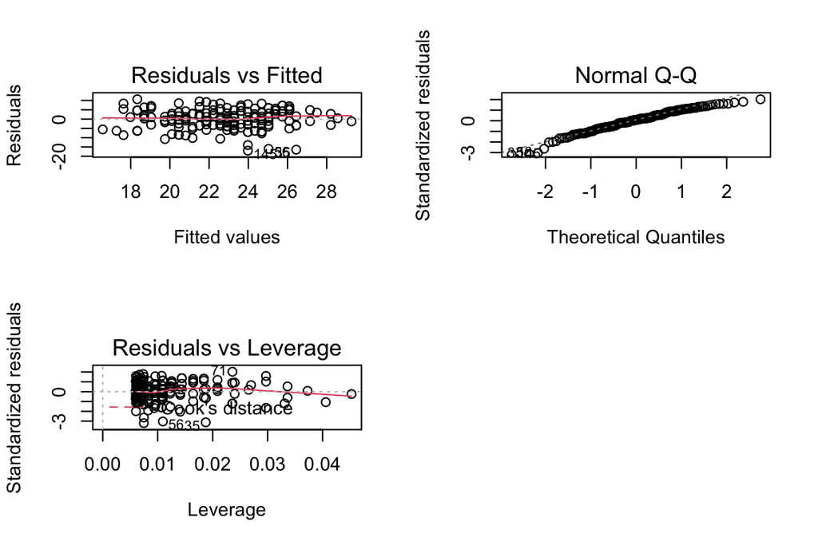

```r
# Produce the following diagnostic plots: Residuals vs Fitted values,
# Normal QQ-plot and Residuals vs Leverage

par(mfrow = c(2,2))

plot(my_model2, which = c(1, 2, 5))
```

In a linear regression model an assumption is linearity: the target variable is modeled as a linear combination of the mode parameters. Usually it is assumed that the errors are normally distributed. By analyzing the residuals of the model we can explore the validity of the model assumptions. It is also assumed that the errors are not correlated, they have constant variance and the size of a given error does not depend on the explanatory variables.

**Residuals vs Fitted values**  
The constant variance assumption implies that the size of the errors should not depend on the explanatory variables. This can be checked with a scatter plot of residuals versus model predictions. A residual is a measure of how well line fits an individual data point. The closer a data point’s residual is to 0, the better fit. The linearity seems to mainly hold as the red line is close to the dashed line in the plot. Potential problematic cases are with the row numbers 35, 56 and 145.

**Normal QQ-plot, normality of the errors**  
QQ-plot of the residuals is a method to explore the assumption that the errors of the model are normally distributed. In the plot the data points seem to be approximately forming a line according to the dash line verifying the assumption of the residual being normally distributed. Potential problematic cases are with the row numbers 35, 56 and 145.

**Residuals vs Leverage, leverage of observations**  
Leverage measures how much impact a single observation has on the model and the residuals vs leverage plot can be used to identify which observations have an unusually high impact. In the plot most of the cases are well inside of the Cook’s distance lines and the red line follows the dashed line quite well. It seems there’s no major impact of single observations on the model. When data points are outside of a dashed line, Cook’s distance, the cases may be influential to the regression results. Potential problematic cases are with the row numbers 35, 56 and 71.

# **Logistic regression**

### **1. Structure of the data**

The data are from two identical questionnaires related to secondary school student alcohol comsumption in Portugal. Data source can be found here: UCI Machine Learning Repository (http://archive.ics.uci.edu/ml/dataset). Metadata is available at: https://archive.ics.uci.edu/ml/datasets/Student+Performance.

A new analysis dataset pormath was created by joining math course and Portuguese language course datasets. The two data sets were joined using all other variables than “failures”, “paid”, “absences”, “G1”, “G2”, “G3” as (student) identifiers.

```r
## RStudio Exercise 3: Analysis
date()
```

```
## [1] "Sun Nov 28 19:52:54 2021"
```

```r
# read in the joined student alcohol consumption data pormath, using read.csv()
pormath <- read.csv('~/IODS-project/data/pormath.csv')

# introduction of the dataset pormath, structure of the data
str(pormath)
```

```
## 'data.frame':    370 obs. of  51 variables:
##  $ school    : chr  "GP" "GP" "GP" "GP" ...
##  $ sex       : chr  "F" "F" "F" "F" ...
##  $ age       : int  15 15 15 15 15 15 15 15 15 15 ...
##  $ address   : chr  "R" "R" "R" "R" ...
##  $ famsize   : chr  "GT3" "GT3" "GT3" "GT3" ...
##  $ Pstatus   : chr  "T" "T" "T" "T" ...
##  $ Medu      : int  1 1 2 2 3 3 3 2 3 3 ...
##  $ Fedu      : int  1 1 2 4 3 4 4 2 1 3 ...
##  $ Mjob      : chr  "at_home" "other" "at_home" "services" ...
##  $ Fjob      : chr  "other" "other" "other" "health" ...
##  $ reason    : chr  "home" "reputation" "reputation" "course" ...
##  $ guardian  : chr  "mother" "mother" "mother" "mother" ...
##  $ traveltime: int  2 1 1 1 2 1 2 2 2 1 ...
##  $ studytime : int  4 2 1 3 3 3 3 2 4 4 ...
```

[output cut: 37 more lines]

```r
# print out names of the variables
colnames(pormath)
```

```
##  [1] "school"     "sex"        "age"        "address"    "famsize"
##  [6] "Pstatus"    "Medu"       "Fedu"       "Mjob"       "Fjob"
## [11] "reason"     "guardian"   "traveltime" "studytime"  "schoolsup"
## [16] "famsup"     "activities" "nursery"    "higher"     "internet"
## [21] "romantic"   "famrel"     "freetime"   "goout"      "Dalc"
## [26] "Walc"       "health"     "n"          "id.p"       "id.m"
## [31] "failures"   "paid"       "absences"   "G1"         "G2"
## [36] "G3"         "failures.p" "paid.p"     "absences.p" "G1.p"
## [41] "G2.p"       "G3.p"       "failures.m" "paid.m"     "absences.m"
## [46] "G1.m"       "G2.m"       "G3.m"       "alc_use"    "high_use"
## [51] "cid"
```

```r
# rows and columns in the dataset
dim(pormath)
```

```
## [1] 370  51
```

The pormath dataset is a dataframe with 370 observations (rows) and 51 variables (columns). The observations represent students and each column contains values of one variable.

### **2. Variables for logistic regression analysis**

Let’s choose 4 variables and create hypotheses for logistic regression.

**The variables:**  
freetime: free time after school (numeric: from 1 - very low to 5 - very high)  
absences: number of school absences (numeric: from 0 to 93)  
age: student’s age (numeric: from 15 to 22)  
goout: going out with friends (numeric: from 1 - very low to 5 - very high)

**The hypotheses:**  
**1**: students with free time have a higher probability to high alcohol consumption than students with less free time  
**2**: students with absences have a higher probability to consume more alcohol than students with less absences  
**3**: older students have a higher probability to high alcohol consumption than younger students  
**4**: students who go out with friends have a higher probability to high alcohol consumption than students who go out less with their friends

### **3. Numerical and graphical overview of the variables**

Numerical overview of the data can be done for example by exploring the **frequencies of the variables in cross tables** and **basic statistic summaries** of the variables using table() and summary() R functions.

```r
## frequencies of the variables, cross tables

# low and high alcohol consumption
summary(as.factor(pormath$high_use))
```

```
## FALSE  TRUE
##   259   111
```

```r
# alcohol consumption and freetime
table(high_use = pormath$high_use, freetime = pormath$freetime)
```

```
##         freetime
## high_use   1   2   3   4   5
##    FALSE  15  46 112  65  21
##    TRUE    2  14  40  40  15
```

```r
# alcohol consumption and absences
table(high_use = pormath$high_use, absences = pormath$absences)
```

```
##         absences
## high_use  0  1  2  3  4  5  6  7  8  9 10 11 12 13 14 16 17 18 19 20 21 26 27
##    FALSE 50 37 40 31 24 16 16  9 14  5  5  2  3  1  1  0  0  1  0  2  1  0  0
##    TRUE  13 13 16  7 11  6  5  3  6  6  2  3  4  1  6  1  1  1  1  0  1  1  1
##         absences
## high_use 29 44 45
##    FALSE  0  0  1
##    TRUE   1  1  0
```

```r
# alcohol consumption and age
table(high_use = pormath$high_use, age = pormath$age)
```

```
##         age
## high_use 15 16 17 18 19 20 22
##    FALSE 63 74 62 52  7  1  0
##    TRUE  18 28 35 25  4  0  1
```

```r
# alcohol consumption and going out with friends
table(high_use = pormath$high_use, goout = pormath$goout)
```

```
##         goout
## high_use  1  2  3  4  5
##    FALSE 19 82 97 40 21
##    TRUE   3 15 23 38 32
```

```r
# select variables freetime, absences, age, goout for joined summary statistics
myvars <- c("freetime", "absences", "age", "goout")
new_pormath <- pormath[myvars]
# print basic statistic summary
summary(new_pormath)
```

```
##     freetime        absences           age            goout
##  Min.   :1.000   Min.   : 0.000   Min.   :15.00   Min.   :1.000
##  1st Qu.:3.000   1st Qu.: 1.000   1st Qu.:16.00   1st Qu.:2.000
##  Median :3.000   Median : 3.000   Median :17.00   Median :3.000
##  Mean   :3.224   Mean   : 4.511   Mean   :16.58   Mean   :3.116
##  3rd Qu.:4.000   3rd Qu.: 6.000   3rd Qu.:17.00   3rd Qu.:4.000
##  Max.   :5.000   Max.   :45.000   Max.   :22.00   Max.   :5.000
```

```r
# access library psych
library(psych)
# create summary table
describe(pormath[ , c('freetime', 'absences', 'age', 'goout')], fast = TRUE)
```

```
##          vars   n  mean   sd min max range   se
## freetime    1 370  3.22 0.99   1   5     4 0.05
## absences    2 370  4.51 5.50   0  45    45 0.29
## age         3 370 16.58 1.18  15  22     7 0.06
## goout       4 370  3.12 1.13   1   5     4 0.06
```

We can see the minimum, first quartile, median, third quartile and maximum values of the freetime, absences, age and goout variables with the summary function. Summary table created with describe() function outputs also column number (vars), number of valid cases (n), standard deviation (sd) and standard error (se) for the variables.

Let’s draw **bar plots** for each variable.

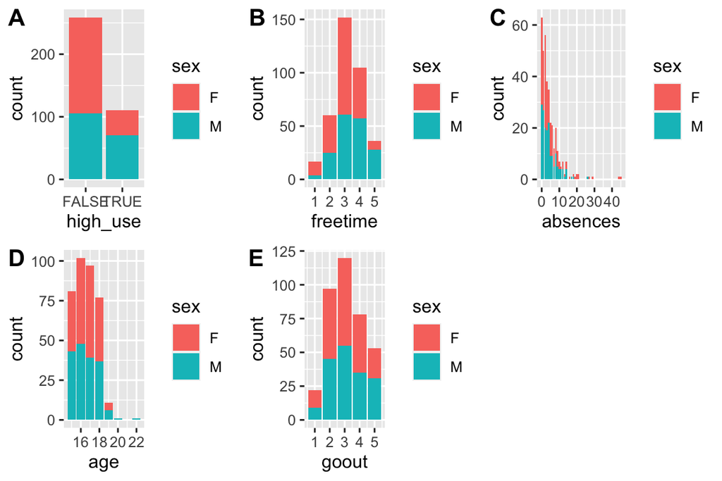

```r
## bar plots to describe distributions of the variables

# access the libraries tidyr, dplyr, ggplot2 and cowplot
library(tidyr)
library(dplyr)
library(ggplot2)
library(cowplot)

# bar plots for each variable
g1 <- ggplot(pormath, aes(x = high_use, fill = sex)) + geom_bar()
g2 <- ggplot(pormath, aes(x = freetime, fill = sex)) + geom_bar()
g3 <- ggplot(pormath, aes(x = absences, fill = sex)) + geom_bar()
g4 <- ggplot(pormath, aes(x = age, fill = sex)) + geom_bar()
g5 <- ggplot(pormath, aes(x = goout, fill = sex)) + geom_bar()

# draw all bar plots
plot_grid(g1, g2, g3, g4, g5, labels="AUTO")
```

The bar plots show counts for each variable by gender. Approximately third of the students report high alcohol consumption and of those students the majority are the male students. Most of the students have average (3) or high amount (4) of freetime after school and have approximately 0 to 14 of absences. Majority of the students are between 15 to 18 years of age and the gender distribution is roughly even for male and female students. Going out with friends vary mainly from low (2) to very high (5)

Let’s draw **box plots** to see the relationships of the variables with the alcohol consumption

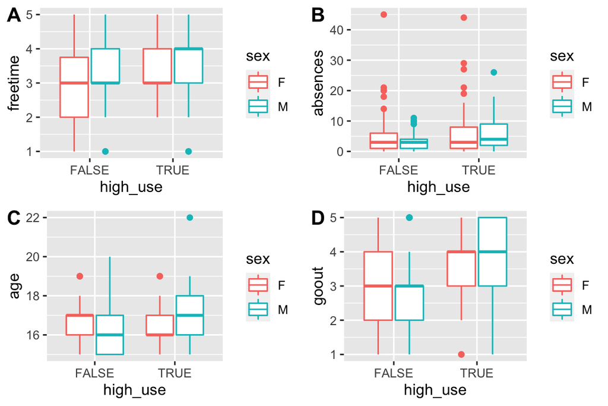

```r
## box plots to describe distributions of the variables
# box plots of the variables

g6 <- ggplot(pormath, aes(x = high_use, y = freetime, col = sex)) + geom_boxplot() + ylab("freetime")
g7 <- ggplot(pormath, aes(x = high_use, y = absences, col = sex)) + geom_boxplot() + ylab("absences")
g8 <- ggplot(pormath, aes(x = high_use, y = age, col = sex)) + geom_boxplot() + ylab("age")
g9 <- ggplot(pormath, aes(x = high_use, y = goout, col = sex)) + geom_boxplot() + ylab("goout")

# draw boxplots
plot_grid(g6, g7, g8, g9, labels = "AUTO")
```

In the box plots the median marks the mid-point of the data and is shown by the line that divides the box into two parts. Half the data points are greater than or equal to this value and half are less. The middle “box” represents the middle 50% of data points for the analysis group. Outliers are shown as dots outside the boxes. The box plots display the distribution of the data, if the data is symmetrical, how tightly the data is grouped and if and how the data is skewed. The whiskers are the two lines outside the box, that go from the minimum to the lower quartile (the start of the box) and then from the upper quartile (the end of the box) to the maximum.

We can see from the box plots that:  
**High alcohol consumption and freetime**  
- females with low alcohol consumption have greater variability in freetime and less freetime than males with low or high alcohol consumption or females with high alcohol consumption. Roughly it seems that amount of freetime after school doesn’t influence much on alcohol consumption.  
**High alcohol consumption and absences**  
- the number of absences is higher for both females and males who report high alcohol consumption.  
**High alcohol consumption and age**  
- males with high alcohol use are a bit older than males with low alcohol consumption.  
**High alcohol consumption and going out with friends**  
- both female and male students who go out more with friends have higher alcohol consumption.

Based on these box plots hypothesis number 2 (students with more absences consume more alcohol than students with less absences) and number 4 (students who go out with friends consume more alcohol than students who go out less with their friends) could hold. The hypothesis 3 (older students consume more alcohol than younger students) might not hold for the whole group of students.

### **4. Fitting the logistic regression model**

The logistic regression model is a genearalized linear model (GLM). It can be used to assess the effects of a set of explanatory variables on a binary response variable. The response in the logistic regression formula is the log odds of a binary outcome of 1.

Let’s fit the logistic regression model. The binary high/low alcohol consumption variable is the target variable. In R, to fit a logistic regression, the glm function is used with the family parameter set to binomial.

```r
# create logistic regression model
model <- glm(high_use ~ freetime + absences + age + goout, data = pormath, family = "binomial")

# print summary of the model
summary(model)
```

```
##
## Call:
## glm(formula = high_use ~ freetime + absences + age + goout, family = "binomial",
##     data = pormath)
##
## Deviance Residuals:
##     Min       1Q   Median       3Q      Max
## -1.7891  -0.7617  -0.5500   0.9668   2.3609
##
## Coefficients:
##             Estimate Std. Error z value Pr(>|z|)
## (Intercept) -5.18857    1.85646  -2.795 0.005192 **
## freetime     0.18307    0.13719   1.334 0.182071
## absences     0.07660    0.02239   3.421 0.000625 ***
## age          0.06957    0.10882   0.639 0.522605
## goout        0.67244    0.12381   5.431 5.59e-08 ***
## ---
## Signif. codes:  0 '***' 0.001 '**' 0.01 '*' 0.05 '.' 0.1 ' ' 1
##
## (Dispersion parameter for binomial family taken to be 1)
##
##     Null deviance: 452.04  on 369  degrees of freedom
## Residual deviance: 388.17  on 365  degrees of freedom
## AIC: 398.17
##
## Number of Fisher Scoring iterations: 4
```

In the summary of the logistic regression model, call shows the function and parameters used to create the model. Deviance is a measure of goodness of fit of a genearalized linear model. The null deviance shows how well the target variable is predicted by the model that includes only the intercept. The residual deviance shows how well the response variable can be predicted by a model with predictor variables.

**High alcohol consumption and absences**  
Each unit increase in absences increases the log odds of high alcohol consumption by 0.0766 and p-value indicates that it is statistically significant in determining the high alcohol consumption

**High alcohol consumption and going out with friends**  
Each unit increase in going out with friends increases the log odds of high alcohol consumption by 0.672 and p-value indicates that it is statistically significant in determining the high alcohol consumption

The variables freetime and age are not statistically significant, meaning that these variables do not have a statistically significant relationship with the binary target variable high/low alcohol consumption.

The estimated parameters in the logistic regression model can be interpreted in terms of odds and odds ratios. The exponents of the coefficients of a logistic regression model can be interpret as odds ratios between a unit change (vs no change) in the corresponding explanatory variable. Let’s print the coefficients of the model as **odds ratios** and **confidence intervals** for them.

```r
# model with statistically significant variables
model2 <- glm(high_use ~ absences + goout, data = pormath, family = "binomial")

# print the coefficients of the model
coef(model2)
```

```
## (Intercept)    absences       goout
## -3.63280208  0.07631808  0.73380079
```

```r
# compute odds ratios (OR)
OR <- coef(model2) %>% exp

# compute confidence intervals (CI)
CI <- confint(model2) %>% exp
# print out the odds ratios with their 95% confidence intervals
cbind(OR, CI)
```

```
##                     OR      2.5 %     97.5 %
## (Intercept) 0.02644199 0.01082308 0.06045431
## absences    1.07930582 1.03477610 1.13034717
## goout       2.08298255 1.66258410 2.64170298
```

The odds ratio (OR) 1.08 with confidence intervals 1.035 to 1.13 for absences means that there is a 3.5% to 13% increase in the odds that students with absences have a higher alcohol consumption compared to students with less absences.

The odds ratio (OR) 2.08 with confidence intervals 1.66 to 2.64 for goout variable means that there is 1.7 to 2.6 times the odds of high alcohol consumption for students who go out with friends compared to students who go out less with their friends.

### **5. Interpreting the predictive power of the logistic regression model**

Let’s explore the predictive power of the logistic regression model to know how well the model actually predicts the target value.

```r
# fit the model
model2 <- glm(high_use ~ absences, goout, data = pormath, family = "binomial")

# predict the probability of high_use
probabilities <- predict(model2, type = "response")

# add the predicted probabilities to pormath
pormath <- mutate(pormath, probability = probabilities)

# use the probabilities to make a prediction of high_use
pormath <- mutate(pormath, prediction = probability > 0.5)

# tabulate the target variable versus the predictions (2x2 cross table)
table(high_use = pormath$high_use, prediction = pormath$prediction)
```

```
##         prediction
## high_use FALSE TRUE
##    FALSE   247   12
##    TRUE     88   23
```

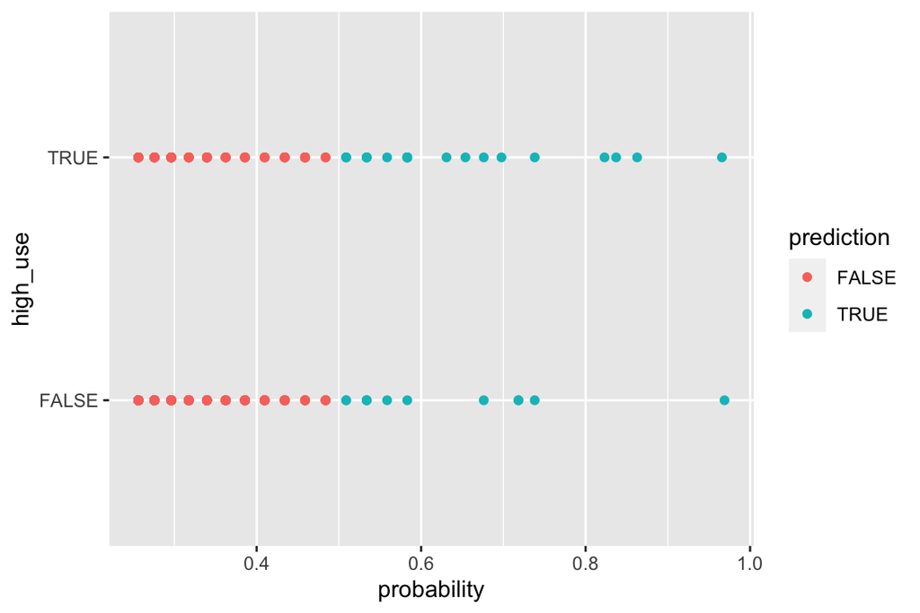

```r
# initialize a plot of 'high_use' versus 'probability' in 'pormath'
g <- ggplot(pormath, aes(x = probability, y = high_use, col = prediction))

# define the geom as points and draw the plot
g + geom_point()
```

```r
# tabulate the target variable versus the predictions
table(high_use = pormath$high_use, prediction = pormath$prediction) %>% prop.table %>% addmargins
```

```
##         prediction
## high_use      FALSE       TRUE        Sum
##    FALSE 0.66756757 0.03243243 0.70000000
##    TRUE  0.23783784 0.06216216 0.30000000
##    Sum   0.90540541 0.09459459 1.00000000
```

```r
# define a loss function (mean prediction error)
loss_func <- function(class, prob) {
  n_wrong <- abs(class - prob) > 0.5
  mean(n_wrong)
}

# call loss_func to compute the average number of wrong predictions in the (training) data
loss_func(class = pormath$high_use, prob = 0)
```

```
## [1] 0.3
```

The first 2x2 cross table is a confusion matrix of predictions versus the actual values of high use of alcohol. The plot displays a graphic visualizing of the actual values and the predictions. The second cross table presents the target variable versus the predicted probabilities. In the tables the predicted outcomes are columns and the true outcomes are the rows. The diagonal elements of the tables show the correct predictions and the off-diagonal elements show the incorrect predictions.

# **Clustering and classification**

### **1. Structure of the data**

We’re using the Boston dataset from the MASS package which is already loaded in R and the details of the data source can be found here: https://stat.ethz.ch/R-manual/R-devel/library/MASS/html/Boston.html

The Boston dataset is a dataframe with 506 observations (rows) and 14 variables (columns). All the variables have numerical values.

Meaning of the variable abbreviations:  
crim = per capita crime rate by town  
zn = proportion of residential land zoned for lots over 25,000 sq.ft  
indus = proportion of non-retail business acres per town  
chas = Charles River dummy variable (= 1 if tract bounds river; 0 otherwise)  
nox = nitrogen oxides concentration (parts per 10 million)  
rm = average number of rooms per dwelling  
age = proportion of owner-occupied units built prior to 1940  
dis = weighted mean of distances to five Boston employment centres  
rad = index of accessibility to radial highways  
tax = full-value property-tax rate per $10,000  
ptratio = pupil-teacher ratio by town  
black = 1000(Bk - 0.63)^2 where Bk is the proportion of blacks by town  
lstat = lower status of the population (percent)  
medv = median value of owner-occupied homes in $1000s

```r
## RStudio Exercise 4: Analysis
date()
```

```
## [1] "Sun Nov 28 19:52:58 2021"
```

```r
# access the MASS package
library(MASS)
# read in data
data("Boston")

## explore the dataset
# structure
str(Boston)
```

```
## 'data.frame':    506 obs. of  14 variables:
##  $ crim   : num  0.00632 0.02731 0.02729 0.03237 0.06905 ...
##  $ zn     : num  18 0 0 0 0 0 12.5 12.5 12.5 12.5 ...
##  $ indus  : num  2.31 7.07 7.07 2.18 2.18 2.18 7.87 7.87 7.87 7.87 ...
##  $ chas   : int  0 0 0 0 0 0 0 0 0 0 ...
##  $ nox    : num  0.538 0.469 0.469 0.458 0.458 0.458 0.524 0.524 0.524 0.524 ...
##  $ rm     : num  6.58 6.42 7.18 7 7.15 ...
##  $ age    : num  65.2 78.9 61.1 45.8 54.2 58.7 66.6 96.1 100 85.9 ...
##  $ dis    : num  4.09 4.97 4.97 6.06 6.06 ...
##  $ rad    : int  1 2 2 3 3 3 5 5 5 5 ...
##  $ tax    : num  296 242 242 222 222 222 311 311 311 311 ...
##  $ ptratio: num  15.3 17.8 17.8 18.7 18.7 18.7 15.2 15.2 15.2 15.2 ...
##  $ black  : num  397 397 393 395 397 ...
##  $ lstat  : num  4.98 9.14 4.03 2.94 5.33 ...
##  $ medv   : num  24 21.6 34.7 33.4 36.2 28.7 22.9 27.1 16.5 18.9 ...
```

```r
# dimensions (rows and columns of the data)
dim(Boston)
```

```
## [1] 506  14
```

### **2. Graphical overview of the data**

Let’s print the **summary statistics** and a **plot matrix** of the Boston data.

```r
# summary statistics
summary(Boston)
```

```
##       crim                zn             indus            chas
##  Min.   : 0.00632   Min.   :  0.00   Min.   : 0.46   Min.   :0.00000
##  1st Qu.: 0.08205   1st Qu.:  0.00   1st Qu.: 5.19   1st Qu.:0.00000
##  Median : 0.25651   Median :  0.00   Median : 9.69   Median :0.00000
##  Mean   : 3.61352   Mean   : 11.36   Mean   :11.14   Mean   :0.06917
##  3rd Qu.: 3.67708   3rd Qu.: 12.50   3rd Qu.:18.10   3rd Qu.:0.00000
##  Max.   :88.97620   Max.   :100.00   Max.   :27.74   Max.   :1.00000
##       nox               rm             age              dis
##  Min.   :0.3850   Min.   :3.561   Min.   :  2.90   Min.   : 1.130
##  1st Qu.:0.4490   1st Qu.:5.886   1st Qu.: 45.02   1st Qu.: 2.100
##  Median :0.5380   Median :6.208   Median : 77.50   Median : 3.207
##  Mean   :0.5547   Mean   :6.285   Mean   : 68.57   Mean   : 3.795
##  3rd Qu.:0.6240   3rd Qu.:6.623   3rd Qu.: 94.08   3rd Qu.: 5.188
##  Max.   :0.8710   Max.   :8.780   Max.   :100.00   Max.   :12.127
##       rad              tax           ptratio          black
##  Min.   : 1.000   Min.   :187.0   Min.   :12.60   Min.   :  0.32
##  1st Qu.: 4.000   1st Qu.:279.0   1st Qu.:17.40   1st Qu.:375.38
##  Median : 5.000   Median :330.0   Median :19.05   Median :391.44
##  Mean   : 9.549   Mean   :408.2   Mean   :18.46   Mean   :356.67
##  3rd Qu.:24.000   3rd Qu.:666.0   3rd Qu.:20.20   3rd Qu.:396.23
##  Max.   :24.000   Max.   :711.0   Max.   :22.00   Max.   :396.90
##      lstat            medv
##  Min.   : 1.73   Min.   : 5.00
##  1st Qu.: 6.95   1st Qu.:17.02
##  Median :11.36   Median :21.20
##  Mean   :12.65   Mean   :22.53
##  3rd Qu.:16.95   3rd Qu.:25.00
##  Max.   :37.97   Max.   :50.00
```

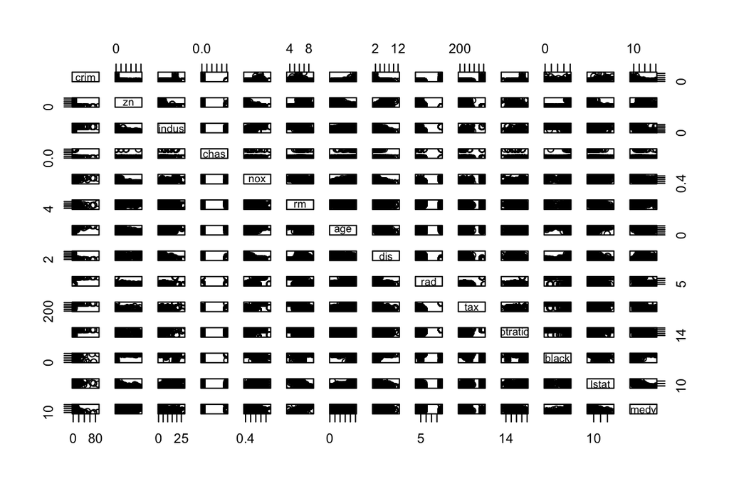

```r
# plot matrix of the variables
pairs(Boston)
```

Let’s draw a **correlation matrix** and a **correlation plot**.

```r
# access libraries
library(MASS)
library(tidyr)
library(corrplot)
# calculate the correlation matrix and round it
cor_matrix <-  cor(Boston) %>% round(digits = 2)

# print the correlation matrix
cor_matrix
```

```
##          crim    zn indus  chas   nox    rm   age   dis   rad   tax ptratio
## crim     1.00 -0.20  0.41 -0.06  0.42 -0.22  0.35 -0.38  0.63  0.58    0.29
## zn      -0.20  1.00 -0.53 -0.04 -0.52  0.31 -0.57  0.66 -0.31 -0.31   -0.39
## indus    0.41 -0.53  1.00  0.06  0.76 -0.39  0.64 -0.71  0.60  0.72    0.38
## chas    -0.06 -0.04  0.06  1.00  0.09  0.09  0.09 -0.10 -0.01 -0.04   -0.12
## nox      0.42 -0.52  0.76  0.09  1.00 -0.30  0.73 -0.77  0.61  0.67    0.19
## rm      -0.22  0.31 -0.39  0.09 -0.30  1.00 -0.24  0.21 -0.21 -0.29   -0.36
## age      0.35 -0.57  0.64  0.09  0.73 -0.24  1.00 -0.75  0.46  0.51    0.26
## dis     -0.38  0.66 -0.71 -0.10 -0.77  0.21 -0.75  1.00 -0.49 -0.53   -0.23
## rad      0.63 -0.31  0.60 -0.01  0.61 -0.21  0.46 -0.49  1.00  0.91    0.46
## tax      0.58 -0.31  0.72 -0.04  0.67 -0.29  0.51 -0.53  0.91  1.00    0.46
## ptratio  0.29 -0.39  0.38 -0.12  0.19 -0.36  0.26 -0.23  0.46  0.46    1.00
## black   -0.39  0.18 -0.36  0.05 -0.38  0.13 -0.27  0.29 -0.44 -0.44   -0.18
## lstat    0.46 -0.41  0.60 -0.05  0.59 -0.61  0.60 -0.50  0.49  0.54    0.37
## medv    -0.39  0.36 -0.48  0.18 -0.43  0.70 -0.38  0.25 -0.38 -0.47   -0.51
##         black lstat  medv
## crim    -0.39  0.46 -0.39
## zn       0.18 -0.41  0.36
## indus   -0.36  0.60 -0.48
## chas     0.05 -0.05  0.18
## nox     -0.38  0.59 -0.43
## rm       0.13 -0.61  0.70
## age     -0.27  0.60 -0.38
## dis      0.29 -0.50  0.25
## rad     -0.44  0.49 -0.38
## tax     -0.44  0.54 -0.47
## ptratio -0.18  0.37 -0.51
## black    1.00 -0.37  0.33
## lstat   -0.37  1.00 -0.74
## medv     0.33 -0.74  1.00
```

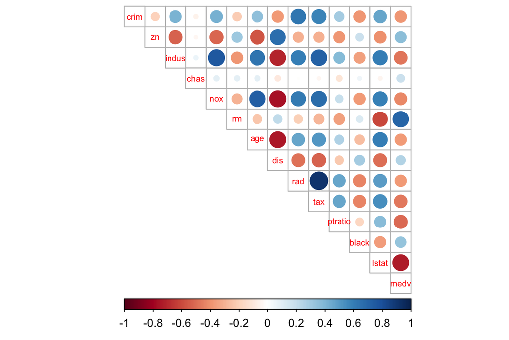

```r
# visualize the correlation matrix
corrplot(cor_matrix, method="circle", type="upper", cl.pos="b", tl.pos="d", tl.cex = 0.6)
```

Correlations between the variables can be calculated with function cor() to create the correlation matrix. The correlation matrix shows correlation coefficients between variables. Correlations plot with corrplot() function visualizes the correlations between variables in the data. The stronger the red color is, the stronger the negative correlation is between the variables in the plot. The strong blue color indicates strong positive correlation between the variables. We can see from the plot that the strongest negative correlation is between indus-dis, nox-dis, age-dis and lstat-medv variable pairs. The strongest positive correlation is between indus-nox, indus-tax, nox-age, rm-medv and rad-tax variable pairs.

### **3. Editing the data for linear discriminant analysis**

Here we’re scaling the data by substracting the column means from the corresponding columns and dividing the difference with standard deviation with scale() function. The scaling makes sense since we have multiple variables across different scales in the original Boston data. By scaling we standardize the data, the scale() function centers and scales the columns of a numeric matrix.

```r
# center and standardize variables
boston_scaled <- scale(Boston)

# summaries of the scaled variables
summary(boston_scaled)
```

```
##       crim                 zn               indus              chas
##  Min.   :-0.419367   Min.   :-0.48724   Min.   :-1.5563   Min.   :-0.2723
##  1st Qu.:-0.410563   1st Qu.:-0.48724   1st Qu.:-0.8668   1st Qu.:-0.2723
##  Median :-0.390280   Median :-0.48724   Median :-0.2109   Median :-0.2723
##  Mean   : 0.000000   Mean   : 0.00000   Mean   : 0.0000   Mean   : 0.0000
##  3rd Qu.: 0.007389   3rd Qu.: 0.04872   3rd Qu.: 1.0150   3rd Qu.:-0.2723
##  Max.   : 9.924110   Max.   : 3.80047   Max.   : 2.4202   Max.   : 3.6648
##       nox                rm               age               dis
##  Min.   :-1.4644   Min.   :-3.8764   Min.   :-2.3331   Min.   :-1.2658
##  1st Qu.:-0.9121   1st Qu.:-0.5681   1st Qu.:-0.8366   1st Qu.:-0.8049
##  Median :-0.1441   Median :-0.1084   Median : 0.3171   Median :-0.2790
##  Mean   : 0.0000   Mean   : 0.0000   Mean   : 0.0000   Mean   : 0.0000
##  3rd Qu.: 0.5981   3rd Qu.: 0.4823   3rd Qu.: 0.9059   3rd Qu.: 0.6617
##  Max.   : 2.7296   Max.   : 3.5515   Max.   : 1.1164   Max.   : 3.9566
##       rad               tax             ptratio            black
##  Min.   :-0.9819   Min.   :-1.3127   Min.   :-2.7047   Min.   :-3.9033
##  1st Qu.:-0.6373   1st Qu.:-0.7668   1st Qu.:-0.4876   1st Qu.: 0.2049
##  Median :-0.5225   Median :-0.4642   Median : 0.2746   Median : 0.3808
##  Mean   : 0.0000   Mean   : 0.0000   Mean   : 0.0000   Mean   : 0.0000
##  3rd Qu.: 1.6596   3rd Qu.: 1.5294   3rd Qu.: 0.8058   3rd Qu.: 0.4332
##  Max.   : 1.6596   Max.   : 1.7964   Max.   : 1.6372   Max.   : 0.4406
##      lstat              medv
##  Min.   :-1.5296   Min.   :-1.9063
##  1st Qu.:-0.7986   1st Qu.:-0.5989
##  Median :-0.1811   Median :-0.1449
##  Mean   : 0.0000   Mean   : 0.0000
##  3rd Qu.: 0.6024   3rd Qu.: 0.2683
##  Max.   : 3.5453   Max.   : 2.9865
```

```r
# class of the boston_scaled object
class(boston_scaled)
```

```
## [1] "matrix" "array"
```

```r
# change the object to data frame
boston_scaled <- as.data.frame(boston_scaled)

# summary of the scaled crime rate
summary(boston_scaled$crim)
```

```
##      Min.   1st Qu.    Median      Mean   3rd Qu.      Max.
## -0.419367 -0.410563 -0.390280  0.000000  0.007389  9.924110
```

```r
# create a quantile vector of crim and print it
bins <- quantile(boston_scaled$crim)
bins
```

```
##           0%          25%          50%          75%         100%
## -0.419366929 -0.410563278 -0.390280295  0.007389247  9.924109610
```

```r
# create a categorical variable 'crime'
crime <- cut(boston_scaled$crim, breaks = bins, include.lowest = TRUE, labels = c("low", "med_low", "med_high", "high"))

# look at the table of the new factor crime
table(crime)
```

```
## crime
##      low  med_low med_high     high
##      127      126      126      127
```

```r
# remove original crim from the dataset
boston_scaled <- dplyr::select(boston_scaled, -crim)

# add the new categorical value to scaled data
boston_scaled <- data.frame(boston_scaled, crime)

# number of rows in the Boston dataset
n <- nrow(boston_scaled)

# choose randomly 80% of the rows
ind <- sample(n,  size = n * 0.8)

# create train set
train <- boston_scaled[ind,]

# create test set
test <- boston_scaled[-ind,]
```

Above a categorical variable of the crime rate (scaled) was created using the quantiles as the break points and the old crime rate variable was dropped from the dataset. The dataset was divided to train and test sets in a way that 80% of the data belongs to the train set. We are using the splitted original and train sets to check how well our model works. The training of the model is done with the train set and prediction on new data is done with the test set.

### **4. Fitting the linear discriminant analysis on the train set**

The MASS package provides a function for LDA (linear discriminant analysis) with R. **Linear discriminant analysis** produces results based on the assumptions that variables are normally distributed and the normal distributions for each class share the same covariance matrix. We scaled the data above because of these assumptions before doing the LDA. The LDA is a classification method, it calculates the probabilities for the new observation for belonging in each of the classes. The observation is classified to the class of the highest probability. The LDA finds the linear combination of the variables that separate the target variable classes.

Let’s fit the LDA on the train set and draw the **LDA plot**, the categorical crime rate being the target variable and all the other variables in the dataset as predictor variables.

```r
# linear discriminant analysis
lda.fit <- lda(crime ~ ., data = train)

# print the lda.fit object
lda.fit
```

```
## Call:
## lda(crime ~ ., data = train)
##
## Prior probabilities of groups:
##       low   med_low  med_high      high
## 0.2549505 0.2475248 0.2425743 0.2549505
##
## Group means:
##                   zn      indus         chas        nox         rm        age
## low       0.98973147 -0.9005710 -0.081207697 -0.8609590  0.4062158 -0.8695845
## med_low  -0.07133196 -0.2619076  0.003267949 -0.5370841 -0.1249676 -0.2499533
## med_high -0.37173443  0.1658088  0.089241362  0.3744170  0.1198991  0.4092527
## high     -0.48724019  1.0170891 -0.042983423  1.0458307 -0.3876815  0.8009723
##                 dis        rad        tax     ptratio      black        lstat
## low       0.8630467 -0.6941969 -0.7426803 -0.44271147  0.3810415 -0.754484542
## med_low   0.3263119 -0.5362660 -0.4351988 -0.04320367  0.3152102 -0.096843199
## med_high -0.3503447 -0.3888872 -0.2911756 -0.21135609  0.1056282 -0.004244206
## high     -0.8591078  1.6384176  1.5142626  0.78111358 -0.8431386  0.898338726
##                 medv
## low       0.50207968
## med_low  -0.01117812
## med_high  0.15686502
## high     -0.68708737
##
## Coefficients of linear discriminants:
##                 LD1         LD2         LD3
## zn       0.13001791  0.72323493 -0.89991288
## indus   -0.03297317 -0.23126899  0.32483271
## chas    -0.07925594  0.02111438  0.12122370
## nox      0.45725107 -0.82623064 -1.53593295
## rm      -0.05943515 -0.13201520 -0.16084619
## age      0.27057553 -0.31881844 -0.02318684
## dis     -0.08006305 -0.37284305  0.17903090
## rad      2.99818333  0.95229165 -0.13729411
## tax     -0.01876245 -0.01787998  0.68569841
## ptratio  0.13092839 -0.04793003 -0.31985235
## black   -0.13457657 -0.01118189  0.10242295
## lstat    0.24749513 -0.22264464  0.40045044
## medv     0.19125531 -0.40099962 -0.15198913
##
## Proportion of trace:
##    LD1    LD2    LD3
## 0.9485 0.0374 0.0141
```

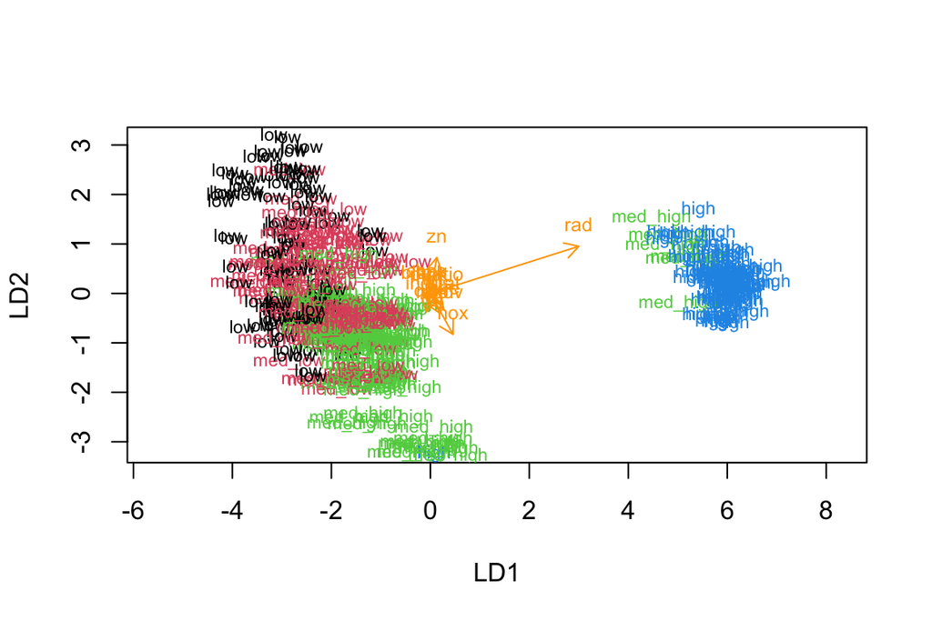

```r
# the function for lda biplot arrows
lda.arrows <- function(x, myscale = 1, arrow_heads = 0.1, color = "orange", tex = 0.75, choices = c(1,2)){
  heads <- coef(x)
  arrows(x0 = 0, y0 = 0,
         x1 = myscale * heads[,choices[1]],
         y1 = myscale * heads[,choices[2]], col=color, length = arrow_heads)
  text(myscale * heads[,choices], labels = row.names(heads),
       cex = tex, col=color, pos=3)
}

# target classes as numeric
classes <- as.numeric(train$crime)

# plot the lda results
plot(lda.fit, dimen = 2, col = classes, pch = classes)
lda.arrows(lda.fit, myscale = 1)
```

### **5. Prediction of values based on the LDA model**

Let’s **predict the categories with the LDA model** on the test data. First, the crime categories from the test set are saved and the categorical crime variable is removed from the test dataset.

```r
# save the correct crime categories from test dataset
correct_classes <- test$crime

# remove the categorical crime variable from the test dataset
test <- dplyr::select(test, -crime)

# predict the classes with the LDA model on the test data
lda.pred <- predict(lda.fit, newdata = test)

# cross tabulate the results with the crime categories from the test set
table(correct = correct_classes, predicted = lda.pred$class)
```

```
##           predicted
## correct    low med_low med_high high
##   low       13      10        1    0
##   med_low    4      18        4    0
##   med_high   0      11       17    0
##   high       0       0        0   24
```

The prediction results with the crime categories from the test set are shown in the cross table above. In the table the predicted outcomes are columns and the true outcomes are the rows. The diagonal elements of the table show the correct predictions and the off-diagonal elements show the incorrect predictions. We can calculate from the cross table that 70.6% (72/102) of the predictions are correct.

### **6. Distance measures and K-means clustering**

**Distances** can be measured with base R’s dist() function. The function creates a distance matrix that is saved as dist object, the distance matrix is usually square matrix containing the pairwise distances of the observations. Similarity (nearness) is determined using a distance metric, which is a function that measureshow far two records are from one another.

To measure the **Euclidean distance** between two vectors, the one is substracted from the other, differences are squared, they are summed, and the squaer root is taken. Another common distance metric for numeric data is **Manhattan distance**. Euclidean distance corresponds to the straight-line distance between two points. Manhattan distance is the distance between two points traversed in a single direction at a time. Different distance measures produce different output.

**Clustering** is a technique to divide data into different groups, where the records on each group are similar to one another. The goal of clustering is to identify significant and meaningful groups of data. **K-means** divides the data into K clusters by minimizing the sum of the squared distances of each record to the mean of its assigned cluster. K-means does not ensure the clusters will have the same size, but finds the clusters that are best separated. It’s typical to standardize continuous variables, otherwise, variables with large scale will dominate the clustering process.

Let’s standardize the Boston dataset and calculate the distances.

```r
# Reload the Boston dataset and standardize the dataset

# load MASS and Boston
library(MASS)
data('Boston')

# standardize the dataset
boston_standardized <- scale(Boston)

## calculate the distances between the observations
# euclidean distance matrix
dist_eu <- dist(boston_standardized)

# look at the summary of the distances
summary(dist_eu)
```

```
##    Min. 1st Qu.  Median    Mean 3rd Qu.    Max.
##  0.1343  3.4625  4.8241  4.9111  6.1863 14.3970
```

```r
# manhattan distance matrix
dist_man <- dist(boston_standardized, method = 'manhattan')

# look at the summary of the distances
summary(dist_man)
```

```
##    Min. 1st Qu.  Median    Mean 3rd Qu.    Max.
##  0.2662  8.4832 12.6090 13.5488 17.7568 48.8618
```

Let’s run k-means algorithm on the Boston dataset. K-means needs the number of clusters as an argument, let’s choose 3. Let’s also visualize the clusters with pairs() function.

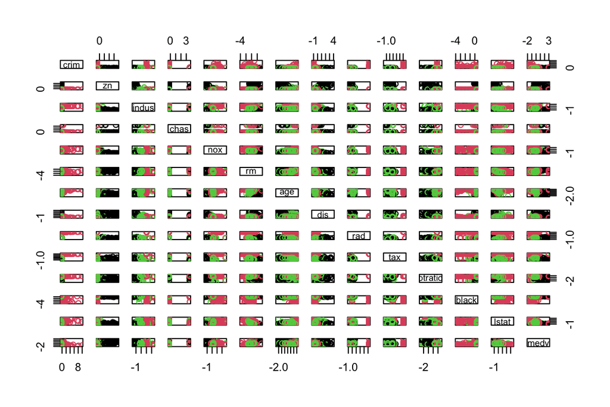

```r
# k-means clustering
km <- kmeans(boston_standardized, centers = 3)

# plot the Boston dataset with clusters
pairs(boston_standardized, col = km$cluster)
```

The clusters seem to somewhat overlap in the plot. To find out the optimal number of clusters, let’s calculate the total of within cluster sum of squares (**WCSS**) and plot the number of clusters and the total WCSS. The optimal number of clusters is when the total WCSS drops radically.

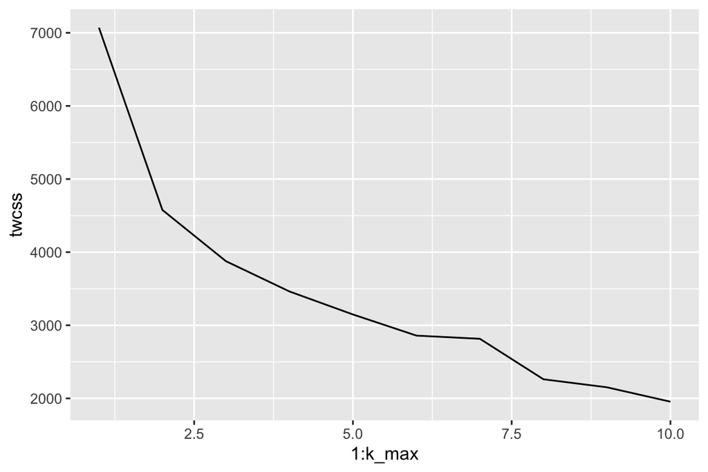

```r
set.seed(123)

# determine the number of clusters
k_max <- 10

# calculate the total within sum of squares
twcss <- sapply(1:k_max, function(k){kmeans(boston_standardized, k)$tot.withinss})

library(plotly)
# visualize the results
qplot(x = 1:k_max, y = twcss, geom = 'line')
```

We can see from the plot that the total WCSS drops radically when number of clusters is 2. Let’s visualize the clusters with pairs() function.

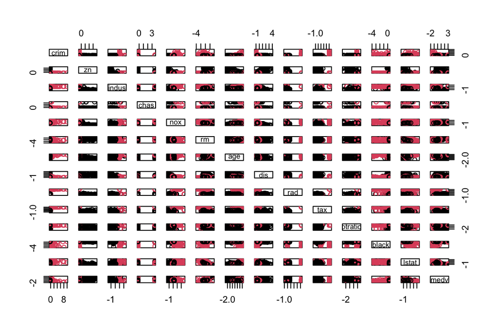

```r
# k-means clustering
km <-kmeans(boston_standardized, centers = 2)

# plot the Boston dataset with clusters
pairs(boston_standardized, col = km$cluster)
```

After repeating the clustering with the optimal number of clusters, 2 differentiated clusters (in black and red color) are now shown in the plot.

(more chapters to be added similarly as we proceed with the course!)